# mtDNA Mutational Analysis - comparator tissues (primarily the ‘non-blood’ dataset)

```r
save_plot(filename = paste0(plots_dir,"dnds_heatmap_by_tissue_and_vaf_by_gene.pdf"),dnds_heatmap_by_tissue_and_vaf_by_gene,width=4,height=6.5)
```

Split into two groups so that can fit in the figure.

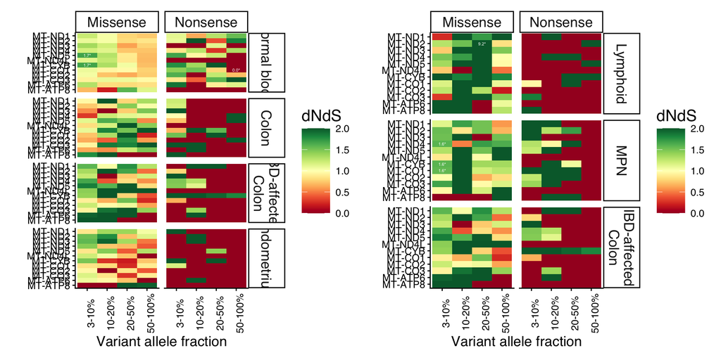

```r
## GROUP 1
group1_tissues<-name_conversion_vec[c(1,4,5,7)]

dnds_heatmap_by_tissue_and_vaf_by_gene_group1<-selcv_res_by_tissue_and_vaf%>%
  mutate(dnds_if_signif=ifelse(qval<qval_cutoff,paste0(sprintf(dNdS, fmt = '%#.1f'),"*"),""),
         dNdS=ifelse(dNdS>2,2,dNdS),
         gene_name=factor(gene_name,levels=rev(gene_order)),
         tissue=factor(name_conversion_vec[tissue],levels=name_conversion_vec))%>%
  filter(VAF_group%in%VAF_groups$labels[-1] & tissue%in%group1_tissues)%>%
  ggplot(aes(y=gene_name,x=VAF_group,fill=dNdS,label=dnds_if_signif))+
  geom_tile()+
  facet_grid(tissue~type)+
  geom_text(col="white",size=1.5)+
  theme_classic()+
  my_markdown_theme+
  theme(axis.text.x=element_text(angle=90))+
  scale_fill_gradientn(colors=RColorBrewer::brewer.pal(n=11,name = "RdYlGn"))+
  labs(x="Variant allele fraction",y="")

## GROUP 2
group2_tissues<-name_conversion_vec[c(2,3,5)]
dnds_heatmap_by_tissue_and_vaf_by_gene_group2<-selcv_res_by_tissue_and_vaf%>%
  mutate(dnds_if_signif=ifelse(qval<qval_cutoff,paste0(sprintf(dNdS, fmt = '%#.1f'),"*"),""),
         dNdS=ifelse(dNdS>2,2,dNdS),
         gene_name=factor(gene_name,levels=rev(gene_order)),
         tissue=factor(name_conversion_vec[tissue],levels=name_conversion_vec))%>%
  filter(VAF_group%in%VAF_groups$labels[-1] & tissue%in%group2_tissues)%>%
  ggplot(aes(y=gene_name,x=VAF_group,fill=dNdS,label=dnds_if_signif))+
  geom_tile()+
  facet_grid(tissue~type)+
  geom_text(col="white",size=1.5)+
  theme_classic()+
  my_markdown_theme+
  theme(axis.text.x=element_text(angle=90))+
  scale_fill_gradientn(colors=RColorBrewer::brewer.pal(n=11,name = "RdYlGn"))+
  labs(x="Variant allele fraction",y="")


save_plot(filename = paste0(plots_dir,"dnds_heatmap_by_tissue_and_vaf_by_gene_group1.pdf"),dnds_heatmap_by_tissue_and_vaf_by_gene_group1,width=3.5,height=4)
save_plot(filename = paste0(plots_dir,"dnds_heatmap_by_tissue_and_vaf_by_gene_group2.pdf"),dnds_heatmap_by_tissue_and_vaf_by_gene_group2,width=3.5,height=3.2)

dnds_heatmap_by_tissue_and_vaf_by_gene_group1+dnds_heatmap_by_tissue_and_vaf_by_gene_group2
```

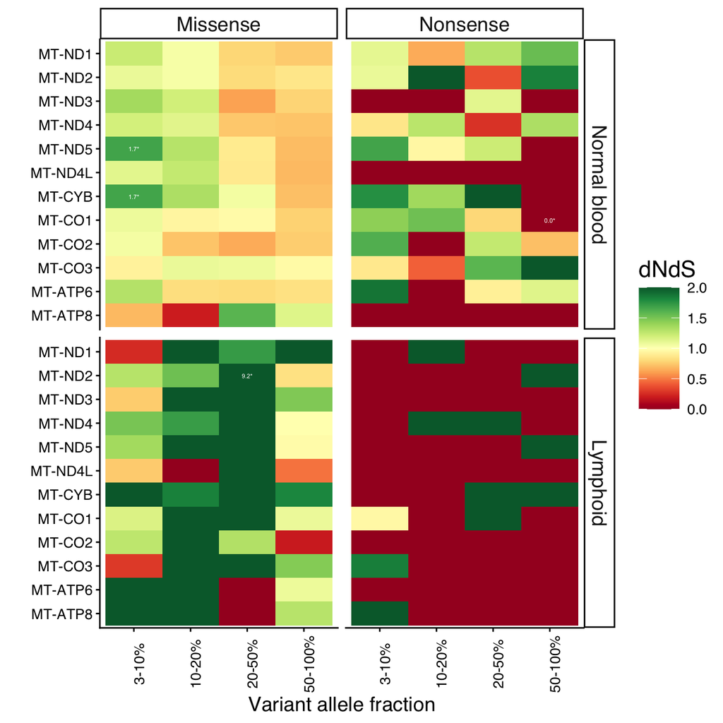

```r
#Now including lymphoid and blood only
dnds_heatmap_by_tissue_and_vaf_by_gene_blood_and_lymph_only<-selcv_res_by_tissue_and_vaf%>%
  mutate(dnds_if_signif=ifelse(qval<qval_cutoff,paste0(sprintf(dNdS, fmt = '%#.1f'),"*"),""),
         dNdS=ifelse(dNdS>2,2,dNdS),
         gene_name=factor(gene_name,levels=rev(gene_order)),
         tissue=factor(name_conversion_vec[tissue],levels=name_conversion_vec))%>%
  filter(VAF_group%in%VAF_groups$labels[-1] & tissue%in%c("Lymphoid","Normal blood"))%>%
  ggplot(aes(y=gene_name,x=VAF_group,fill=dNdS,label=dnds_if_signif))+
  geom_tile()+
  facet_grid(tissue~type)+
  geom_text(col="white",size=1.5)+
  theme_classic()+
  my_markdown_theme+
  theme(axis.text.x=element_text(angle=90))+
  scale_fill_gradientn(colors=RColorBrewer::brewer.pal(n=11,name = "RdYlGn"))+
  labs(x="Variant allele fraction",y="")

dnds_heatmap_by_tissue_and_vaf_by_gene_blood_and_lymph_only
```

```r
save_plot(filename = paste0(plots_dir,"dnds_heatmap_by_tissue_and_vaf_by_gene_blood_and_lymph_only.pdf"),dnds_heatmap_by_tissue_and_vaf_by_gene_blood_and_lymph_only,width=4,height=4)
```

### Split by dichotomous VAF group (less or greater than 20% only)

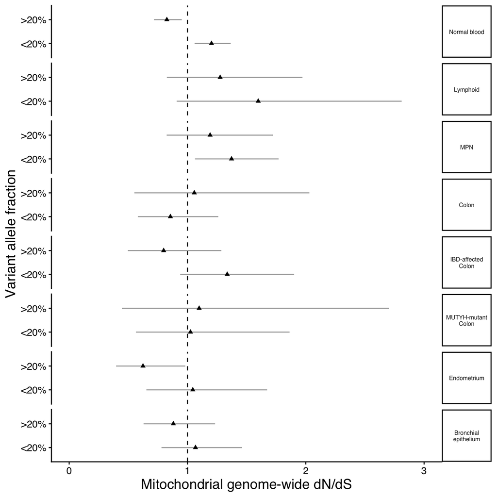

```r
boundaries<-c(0,0.03,0.2,1.000001)
new_VAF_groups=paste0(round(100*head(boundaries,-1)),"-",round(100*tail(boundaries,-1)),"%")
VAF_groups=data.frame(labels=new_VAF_groups,LL=head(boundaries,-1),UL=tail(boundaries,-1))

#Assign each observed VAF into its 'VAF group' bin
all_df_tidy<-lapply(all_df_tidy,function(df_tidy) {
  df_tidy$VAF_group=sapply(df_tidy$vaf,function(vaf) {
    if(vaf==0) {
      return("Absent")
    } else {
      return(VAF_groups$labels[VAF_groups$LL<vaf & VAF_groups$UL>=vaf])
    }
  })
  return(df_tidy)
})

dndscv_by_tissue_and_dichotomous_vaf<-Map(df_tidy=all_df_tidy[all_cohorts],this_tissue=all_cohorts,function(df_tidy,this_tissue) {
  #cat(this_tissue,sep = "\n")
  dndscv_by_vaf_tissue<-lapply(new_VAF_groups[2:length(new_VAF_groups)],function(VAF_bin) {
    #cat(VAF_bin,sep="\n")
    tissue_vaf_info<-df_tidy%>%
      dplyr::filter(VAF_group==VAF_bin)%>%
      separate("mut_ref", c("chr", "pos", "ref", "mut"), "_")%>%
      mutate(pos=as.numeric(pos))%>%
      dplyr::select("sampleID"=exp_ID,chr,pos,ref,mut)%>%
      dplyr::filter(!duplicated(.))%>% #only count each mutation once per individual in each VAF group
      arrange(sampleID,pos)

    mtdna.dndsout <- dndscv(tissue_vaf_info,
                            gene_list=target_genes,
                            refdb = mtref_rda_path,
                            numcode = 2,
                            max_coding_muts_per_sample = Inf,
                            max_muts_per_gene_per_sample = Inf)
    return(mtdna.dndsout)
  })
  return(dndscv_by_vaf_tissue)
})

globaldnds_res_by_tissue_and_dichotomous_vaf<-Map(list1=dndscv_by_tissue_and_dichotomous_vaf,this_tissue=all_cohorts,function(list1,this_tissue) {
  globaldnds_res_by_vaf<-Map(dndsout=list1,VAF_bin=new_VAF_groups[2:length(new_VAF_groups)],function(dndsout,VAF_bin) {
    dndsout$globaldnds%>%
      filter(!is.na(name) & complete.cases(.))%>%
      mutate(name=rename_vec[name])%>%
      mutate(VAF_group=VAF_bin)
  })%>%dplyr::bind_rows()%>%
    mutate(tissue=this_tissue)
})%>%dplyr::bind_rows()

nb.cols <- length(name_conversion_vec)
mycolors <- colorRampPalette(ggsci::pal_lancet(palette = "lanonc")(9))(3)
#mycolors<-ggsci::pal_lancet(palette = "lanonc")(9)

max_dnds_value<-3
stats_to_include=c("Overall")
VAF_conv_vec=c("<20%",">20%")
names(VAF_conv_vec)=c("3-20%","20-100%")
global_dnds_by_tissue_and_dichotomous_vaf_plot<-globaldnds_res_by_tissue_and_dichotomous_vaf%>%
  filter(VAF_group%in%VAF_groups$labels[-1] & name%in%stats_to_include)%>%
  mutate(cihigh=ifelse(cihigh>max_dnds_value,max_dnds_value,cihigh),
         VAF_group=factor(VAF_conv_vec[VAF_group],levels=VAF_conv_vec),
         tissue=factor(name_conversion_vec[tissue],levels=name_conversion_vec))%>%
  ggplot(aes(x=VAF_group, y = mle, ymin = cilow, ymax = cihigh, color = name, shape = name)) +
  geom_hline(yintercept=1, linetype='dashed', col = 'black', linewidth = 0.5) +
  geom_linerange(position= position_dodge2(width=0.75), linewidth = 0.5, color="darkgrey") +
  geom_point(position=position_dodge2(width=0.75), size = 1.5) +
  labs(y = "Mitochondrial genome-wide dN/dS", x = "Variant allele fraction") +
  theme_classic() +
  ylim(c(0,max_dnds_value))+
  scale_color_manual(values = mut_type_cols, name="Mutation type") +
  scale_shape_manual(values = 17, name = "Mutation type") +
  theme_classic()+
  my_markdown_theme+
  facet_grid(rows=vars(tissue))+
  theme(legend.position="none",
        axis.text.x=element_text(angle=0),
        strip.text.y = element_text(angle = 0,size=6))+
  coord_flip()

global_dnds_by_tissue_and_dichotomous_vaf_plot
```

```r
save_plot(filename = paste0(plots_dir,"global_dnds_by_tissue_and_dichotomous_vaf_plot_CROSSTISSUE.pdf"),global_dnds_by_tissue_and_dichotomous_vaf_plot,width=2.5,height=2.5)
```

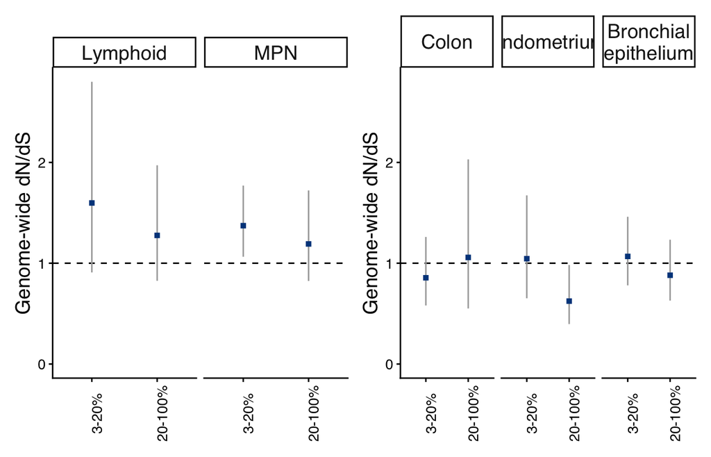

```r
max_dnds_value<-2.8
global_dnds_by_dichotomous_vaf_MPN_and_lymph_onlyplot<-globaldnds_res_by_tissue_and_dichotomous_vaf%>%
  filter(VAF_group%in%VAF_groups$labels[2:nrow(VAF_groups)] & name%in%stats_to_include)%>%
  mutate(cihigh=ifelse(cihigh>max_dnds_value,max_dnds_value,cihigh),
         VAF_group=factor(VAF_group,levels=VAF_groups$labels[2:nrow(VAF_groups)]),
         tissue=factor(name_conversion_vec[tissue],levels=name_conversion_vec))%>%
  filter(tissue%in%c("Lymphoid","MPN"))%>%
  ggplot(aes(x=VAF_group, y = mle, ymin = cilow, ymax = cihigh, color = name, shape = name)) +
  geom_hline(yintercept=1, linetype='dashed', col = 'black', linewidth = 0.5) +
  geom_linerange(position= position_dodge2(width=0.75), linewidth = 0.5, color="darkgrey") +
  geom_point(position=position_dodge2(width=0.75), size = 1.5) +
  labs(y = "Genome-wide dN/dS", x = "Variant allele fraction") +
  theme_classic() +
  ylim(c(0,max_dnds_value))+
  scale_color_manual(values = mycolors[1:2], name="Mutation type") +
  scale_shape_manual(values = c(15, 16, 17, 18), name = "Mutation type") +
  theme_classic()+
  my_markdown_theme+
  facet_grid(cols=vars(tissue))+
  theme(legend.position="none",
        axis.text.x=element_text(angle=90),
        axis.title.x=element_blank(),
        strip.text.y = element_text(angle = 0))

save_plot(filename = paste0(plots_dir,"global_dnds_by_dichotomous_vaf_MPN_and_lymph_onlyplot.pdf"),global_dnds_by_dichotomous_vaf_MPN_and_lymph_onlyplot,width=2,height=2)


global_dnds_by_dichotomous_vaf_normal_nonblood_onlyplot<-globaldnds_res_by_tissue_and_dichotomous_vaf%>%
  filter(VAF_group%in%VAF_groups$labels[-1] & name%in%stats_to_include)%>%
  mutate(cihigh=ifelse(cihigh>max_dnds_value,max_dnds_value,cihigh),
         VAF_group=factor(VAF_group,levels=VAF_groups$labels[-1]),
         tissue=factor(name_conversion_vec[tissue],levels=name_conversion_vec))%>%
  filter(tissue%in%c("Colon","Endometrium","Bronchial\nepithelium"))%>%
  ggplot(aes(x=VAF_group, y = mle, ymin = cilow, ymax = cihigh, color = name, shape = name)) +
  geom_hline(yintercept=1, linetype='dashed', col = 'black', linewidth = 0.5) +
  geom_linerange(position= position_dodge2(width=0.75), linewidth = 0.5, color="darkgrey") +
  geom_point(position=position_dodge2(width=0.75), size = 1.5) +
  labs(y = "Genome-wide dN/dS", x = "Variant allele fraction") +
  theme_classic() +
  ylim(c(0,max_dnds_value))+
  scale_color_manual(values = mycolors[1:2], name="Mutation type") +
  scale_shape_manual(values = c(15, 16, 17, 18), name = "Mutation type") +
  theme_classic()+
  my_markdown_theme+
  facet_grid(cols=vars(tissue))+
  theme(legend.position="none",
        axis.text.x=element_text(angle=90),
        axis.title.x=element_blank(),
        strip.text.y = element_text(angle = 0))


save_plot(filename = paste0(plots_dir,"global_dnds_by_dichotomous_vaf_normal_nonblood_onlyplot.pdf"),global_dnds_by_dichotomous_vaf_normal_nonblood_onlyplot,width=2.5,height=2)

global_dnds_by_dichotomous_vaf_MPN_and_lymph_onlyplot+global_dnds_by_dichotomous_vaf_normal_nonblood_onlyplot
```

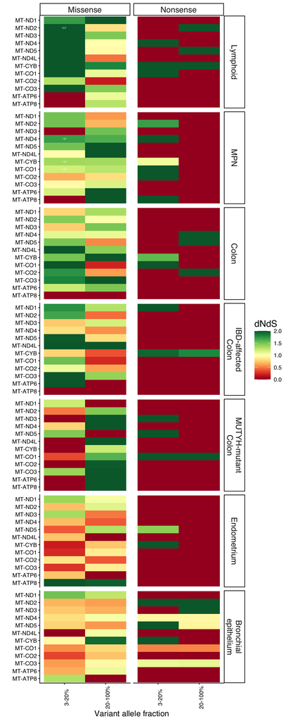

```r
gene_order=c(paste0("MT-ND",1:6),"MT-ND4L","MT-CYB",paste0("MT-CO",1:3),"MT-ATP6","MT-ATP8")
gene_order<-gene_order[gene_order%in%target_genes]

selcv_res_by_tissue_and_dichotomous_vaf<-Map(list1=dndscv_by_tissue_and_vaf,this_tissue=names(dndscv_by_tissue_and_vaf),function(list1,this_tissue) {

  Map(dndsout=list1,VAF_bin=new_VAF_groups[2:length(new_VAF_groups)],function(dndsout,VAF_bin) {
    temp<-dndsout$sel_cv%>%
      dplyr::select(gene_name,wmis_cv,wnon_cv,qmis_cv,qtrunc_cv)

    dplyr::bind_rows(temp%>%dplyr::select(gene_name,"dNdS"=wmis_cv,"qval"=qmis_cv)%>%mutate(type="Missense"),
                     temp%>%dplyr::select(gene_name,"dNdS"=wnon_cv,"qval"=qtrunc_cv)%>%mutate(type="Nonsense"))%>%
      mutate(VAF_group=VAF_bin)
  })%>%dplyr::bind_rows()%>%
    mutate(VAF_group=factor(VAF_group,levels=VAF_groups$labels[2:length(new_VAF_groups)]),tissue=this_tissue)

})%>%dplyr::bind_rows()

dnds_heatmap_by_tissue_and_dichotomous_vaf_by_gene<-selcv_res_by_tissue_and_dichotomous_vaf%>%
  mutate(dnds_if_signif=ifelse(qval<qval_cutoff,paste0(sprintf(dNdS, fmt = '%#.1f'),"*"),""),
         dNdS=ifelse(dNdS>2,2,dNdS),
         gene_name=factor(gene_name,levels=rev(gene_order)),
         tissue=factor(name_conversion_vec[tissue],levels=name_conversion_vec))%>%
  filter(VAF_group%in%VAF_groups$labels[2:nrow(VAF_groups)] & tissue!="Normal blood")%>%
  ggplot(aes(y=gene_name,x=VAF_group,fill=dNdS,label=dnds_if_signif))+
  geom_tile()+
  facet_grid(tissue~type)+
  geom_text(col="white",size=1.5)+
  theme_classic()+
  my_markdown_theme+
  theme(axis.text.x=element_text(angle=90))+
  scale_fill_gradientn(colors=RColorBrewer::brewer.pal(n=11,name = "RdYlGn"))+
  labs(x="Variant allele fraction",y="")

dnds_heatmap_by_tissue_and_dichotomous_vaf_by_gene
```

```r
save_plot(filename = paste0(plots_dir,"dnds_heatmap_by_tissue_and_dichotomous_vaf_by_gene.pdf"),dnds_heatmap_by_tissue_and_dichotomous_vaf_by_gene,width=4,height=6.5)
```

## MPN analysis, test global dNdS by driver clone/ wild-type

```r
#1. Add basic nDNA driver mutation info to the object
all_mito_datasets$NW<-Map(list=all_mito_datasets$NW,exp_ID=names(all_mito_datasets$NW),function(list,exp_ID) {
  annot_muts_file<-paste0(root_dir,"/data/nonblood/annot_files_filtered/annotated_muts_filt_",exp_ID,".Rds")
  #annot_muts_file<-paste0("annotated_muts_filt_",exp_ID,".Rds")
  if(file.exists(annot_muts_file)) {
    cat(paste("Importing annotated mutations dataframe for",exp_ID),sep="\n")
    list$nDNA_mats<-readRDS(annot_muts_file)

    if(nrow(list$nDNA_mats$mat)==0) {
      stop(return(list))
    }

    tree_samples<-list$tree.ultra$tip.label[list$tree.ultra$tip.label!="Ancestral"]

    if(any(!tree_samples%in%colnames(list$nDNA_mats$NV))) {
      cat("Dropping samples not found in the count matrix.")
      drop_tips<-tree_samples[!tree_samples%in%colnames(list$nDNA_mats$NV)]
      list$tree.ultra<-drop.tip(list$tree.ultra,tip = drop_tips)
      list$tree<-drop.tip(list$tree,tip = drop_tips)
      tree_samples<-tree_samples[tree_samples%in%colnames(list$nDNA_mats$NV)]
    }

    # mtr<-as.matrix(cbind(list$nDNA_mats$NV[,tree_samples,drop=F],matrix(0,ncol = 1,nrow = nrow(list$nDNA_mats$NV),dimnames = list(rownames(list$nDNA_mats$NV),"Ancestral"))))
    # dep<-as.matrix(cbind(list$nDNA_mats$NR[,tree_samples,drop=F],matrix(10,ncol = 1,nrow = nrow(list$nDNA_mats$NR),dimnames = list(rownames(list$nDNA_mats$NV),"Ancestral"))))

    mtr<-as.matrix(list$nDNA_mats$NV[,tree_samples,drop=F])
    dep<-as.matrix(list$nDNA_mats$NR[,tree_samples,drop=F])


    res<-treemut::assign_to_tree(tree=list$tree.ultra,mtr=mtr,dep=dep)
    list$nDNA_mats$mat$node<-res$tree$edge[res$summary$edge_ml,2]
    return(list)
  } else {
    return(list)
  }
})

#Generate a similar 'sum of vaf' dataframe, but now incorporating driver information
mut_vs_wt_list<-Map(list=all_mito_datasets$NW,exp_ID=names(all_mito_datasets$NW),function(list,exp_ID) {
  cat(exp_ID,sep="\n")
  #Using the 'get_expanded_clade_nodes' function to effectively cut across the tree at 100 mutations of molecular time
  #Some of the clades will be singletons
  ec_df<-get_expanded_clade_nodes(list$tree.ultra,height_cut_off = 100,min_clonal_fraction = 0,min_samples=1)%>%
    left_join(list$nDNA_mats$mat%>%dplyr::select(node,mut_ref,GENE,CDS),by=c("nodes"="node"))%>%
    mutate(exp_ID=exp_ID,.before=1)

  # genes_of_interest=c("JAK2","TET2","DNMT3A","ASXL1")
  # mut_nodes<-ec_df%>%filter(GENE%in%genes_of_interest)%>%pull(nodes)%>%unique()
  # wt_nodes<-ec_df$nodes[!ec_df$nodes%in%mut_nodes]

  mut_nodes<-ec_df%>%filter(n_samples>1)%>%pull(nodes)
  wt_nodes<-ec_df%>%filter(n_samples==1)%>%pull(nodes)

  mut_samples<-unlist(lapply(mut_nodes,function(node) getTips(list$tree.ultra,node=node)))
  wt_samples<-unlist(lapply(wt_nodes,function(node) getTips(list$tree.ultra,node=node)))

  return(list(mut=mut_samples,wt=wt_samples))
})

all_mut<-unlist(lapply(mut_vs_wt_list,function(x) x$mut))
all_wt<-unlist(lapply(mut_vs_wt_list,function(x) x$wt))

dndscv_by_vaf_and_mut_status<-lapply(list(mut=all_mut,wt=all_wt),function(sample_set) {
  dndscv_by_vaf<-lapply(new_VAF_groups[-1],function(VAF_bin) {
    cat(VAF_bin,sep="\n")
    tissue_vaf_info<-all_df_tidy$NW%>%
      dplyr::filter(Sample%in%sample_set & VAF_group==VAF_bin)%>%
      separate("mut_ref", c("chr", "pos", "ref", "mut"), "_")%>%
      mutate(pos=as.numeric(pos))%>%
      dplyr::select("sampleID"=exp_ID,chr,pos,ref,mut)%>%
      dplyr::filter(!duplicated(.))%>% #only count each mutation once per individual in each VAF group
      arrange(sampleID,pos)

    mtdna.dndsout <- dndscv(tissue_vaf_info,
                            gene_list=target_genes,
                            refdb = mtref_rda_path,
                            numcode=2,
                            max_coding_muts_per_sample = Inf,
                            max_muts_per_gene_per_sample = Inf)
    return(mtdna.dndsout)
  })
  names(dndscv_by_vaf)<-new_VAF_groups[2:nrow(VAF_groups)]
  return(dndscv_by_vaf)
})

global_dnds_by_mut_status<-Map(list1=dndscv_by_vaf_and_mut_status,status=c("mut","wt"),function(list1,status) {

  Map(dndsout=list1,VAF_bin=names(list1),function(dndsout,VAF_bin) {
    dndsout$globaldnds%>%
      filter(!is.na(name) & complete.cases(.))%>%
      mutate(name=rename_vec[name])%>%
      mutate(VAF_group=VAF_bin)
  })%>%dplyr::bind_rows()%>%
    mutate(mut_status=status)

})%>%dplyr::bind_rows()

max_dnds_value<-4
stats_to_include=c("Missense","Truncating")
rename_mut_status_vec=c("MPN clonal expansion","Singleton")
names(rename_mut_status_vec)<-c("mut","wt")

nb.cols <- 2
mycolors <- colorRampPalette(ggsci::pal_lancet(palette = "lanonc")(9))(nb.cols)

MPN_global_dnds_by_mut_status_plot<-global_dnds_by_mut_status%>%
  filter(VAF_group%in%VAF_groups$labels[-1] & name%in%stats_to_include)%>%
  mutate(cihigh=ifelse(cihigh>max_dnds_value,max_dnds_value,cihigh),
         VAF_group=factor(VAF_group,levels=VAF_groups$labels[-1]),
         mut_status=rename_mut_status_vec[mut_status])%>%
  ggplot(aes(x=VAF_group, y = mle, ymin = cilow, ymax = cihigh, color = name, shape = name)) +
  geom_linerange(position= position_dodge2(width=0.75), linewidth = 0.5, color="darkgrey") +
  geom_point(position=position_dodge2(width=0.75), size = 1.5) +
  labs(y = "Genome-wide dN/dS", x = "Variant allele fraction") +
  theme_classic() +
  ylim(c(0,max_dnds_value))+
  scale_color_manual(values = mycolors[1:2], name="Mutation type") +
  scale_shape_manual(values = c(15, 16, 17, 18), name = "Mutation type") +
  geom_hline(yintercept=1, linetype='dashed', col = 'darkgrey', linewidth = 0.5) +
  theme_classic()+
  my_markdown_theme+
  facet_wrap(~mut_status,nrow=1)+
  theme(legend.position="top",axis.text.x=element_text(angle=90))

MPN_global_dnds_by_mut_status_plot
save_plot(filename = paste0(plots_dir,"MPN_global_dnds_by_mut_status_plot.pdf"),MPN_global_dnds_by_mut_status_plot,width=3.5,height=2.5)
```

# MPN analysis, test gene-level dNdS by driver clone/ wild-type and VAF

```r
selcv_res_by_mut_status<-Map(list1=dndscv_by_vaf_and_mut_status,status=c("mut","wt"),function(list1,status) {

  Map(dndsout=list1,VAF_bin=names(list1),function(dndsout,VAF_bin) {
    temp<-dndsout$sel_cv%>%
      dplyr::select(gene_name,wmis_cv,wnon_cv,qmis_cv,qtrunc_cv)

    dplyr::bind_rows(temp%>%dplyr::select(gene_name,"dNdS"=wmis_cv,"qval"=qmis_cv)%>%mutate(type="Missense"),
                     temp%>%dplyr::select(gene_name,"dNdS"=wnon_cv,"qval"=qtrunc_cv)%>%mutate(type="Nonsense"))%>%
      mutate(VAF_group=VAF_bin)
  })%>%dplyr::bind_rows()%>%
    mutate(VAF_group=factor(VAF_group,levels=VAF_groups$labels[2:nrow(VAF_groups)]),mut_status=status)

})%>%dplyr::bind_rows()

nb.cols <- 2
mycolors <- colorRampPalette(ggsci::pal_lancet(palette = "lanonc")(9))(nb.cols)
gene_order=c(paste0("MT-ND",1:6),"MT-ND4L","MT-CYB",paste0("MT-CO",1:3),"MT-ATP6","MT-ATP8")
gene_order<-gene_order[gene_order%in%target_genes]

MPN_dnds_heatmap_by_mut_status_by_gene<-selcv_res_by_mut_status%>%
  mutate(dnds_if_signif=ifelse(qval<0.1,paste0(sprintf(dNdS, fmt = '%#.1f'),"*"),ifelse(dNdS>2,sprintf(dNdS, fmt = '%#.1f'),"")),
         dNdS=ifelse(dNdS>2,2,dNdS),
         gene_name=factor(gene_name,levels=rev(gene_order)),
         mut_status=rename_mut_status_vec[mut_status])%>%
  filter(VAF_group%in%VAF_groups$labels[2:5])%>%
  ggplot(aes(y=gene_name,x=VAF_group,fill=dNdS,label=dnds_if_signif))+
  geom_tile()+
  facet_grid(mut_status~type)+
  geom_text(col="white",size=1.5)+
  theme_classic()+
  my_markdown_theme+
  theme(axis.text.x=element_text(angle=90))+
  scale_fill_gradientn(colors=RColorBrewer::brewer.pal(n=11,name = "RdYlGn"))+
  labs(x="Variant allele fraction",y="")
MPN_dnds_heatmap_by_mut_status_by_gene
save_plot(filename = paste0(plots_dir,"MPN_dnds_heatmap_by_mut_status_by_gene.pdf"),MPN_dnds_heatmap_by_mut_status_by_gene,width=3.5,height=3.5)
```

# HETEROPLASMIC OOCYTE MUT ANALYSIS

### Identify the heteroplasmic oocyte mutations

This is based on the principle that mutations present across multiple unrelated clones (till you go back to development),are most likely to have been present in the oocyte and drifted up in unrelated lineages. The alternative - possible for some of these - are that these are examples of independent acquisition.

```r
all_het_oocyte_mut_df=Map(dataset_mito_data=all_mito_datasets[all_cohorts],dataset=all_cohorts, function(dataset_mito_data,dataset) {
  cat(dataset,sep="\n")
  het_oocyte_mut_df<-Map(list=dataset_mito_data,Exp_ID=names(dataset_mito_data),function(list,Exp_ID){
    cat(Exp_ID,sep="\n")

    #Foetal trees are analysed separately.
    #Only analyse if ≥8 samples
    if(length(list$tree$tip.label)<8){stop(return(NULL))}

    if(Exp_ID%in%c("8 pcw","18 pcw","CB001","CB002")) {
      threshold_vaf<-0.025; threshold_molecular_time<-5; node_height_for_independence<-20
    } else {
      threshold_vaf<-0.25; threshold_molecular_time<-30; node_height_for_independence<-100
    }

    het_oocyte_muts<-detect_het_oocyte_mutation(matrices=list$matrices,tree=list$tree,vaf_cutoff=threshold_vaf)
    if(length(het_oocyte_muts)==0){stop(return(NULL))}

    het_oocyte_muts<-het_oocyte_muts[!het_oocyte_muts%in%exclude_muts & !grepl("DEL|INS",het_oocyte_muts)]
    if(length(het_oocyte_muts)==0){stop(return(NULL))}

    ho_vaf_mat<-list$matrices$vaf[het_oocyte_muts,list$tree$tip.label,drop=F]

    MRCA_mol_times<-sapply(1:nrow(ho_vaf_mat),function(i) {
      pos_samples<-colnames(ho_vaf_mat)[ho_vaf_mat[i,]>threshold_vaf]
      MRCA_node<-find_latest_acquisition_node(tree = list$tree,pos_samples = pos_samples)
      nodeheight(tree=list$tree,node=MRCA_node)
    })

    high_vaf_het_oocyte_muts<-het_oocyte_muts[MRCA_mol_times<threshold_molecular_time]
    ho_vaf_mat<-ho_vaf_mat[MRCA_mol_times<threshold_molecular_time,]

    if(length(high_vaf_het_oocyte_muts)==0){stop(return(NULL))}

    #Most likely oocyte VAF for these mutations
    if(dataset=="lymph"){
      samples_to_include<-list$tree$tip.label
    } else {
      post_dev_nodes<-get_expanded_clade_nodes(tree=list$tree,height_cut_off = node_height_for_independence,min_samples = 1,min_clonal_fraction = 0)
      samples_to_include<-unlist(lapply(post_dev_nodes$nodes,function(node) sample(size=1,x=getTips(list$tree,node))))
    }

    ml_vaf<-sapply(high_vaf_het_oocyte_muts,function(mut_ref) {
      mean(unlist(ho_vaf_mat[mut_ref,samples_to_include,drop=T]))
    })

    df<-data.frame(exp_ID=Exp_ID,
                   vaf_threshold_used_to_define_positive=threshold_vaf,
                   molecular_time_used_to_define_embryonic=threshold_molecular_time,
                   mut_ref=high_vaf_het_oocyte_muts,
                   n_pos=sapply(1:nrow(ho_vaf_mat),function(i) {length(colnames(ho_vaf_mat)[ho_vaf_mat[i,]>threshold_vaf])}),
                   MRCA_molecular_time=MRCA_mol_times[MRCA_mol_times<threshold_molecular_time],
                   ml_vaf=ml_vaf)

    return(df)
  })%>%dplyr::bind_rows()%>%
    mutate(dataset=dataset,.before=1)

  return(het_oocyte_mut_df)
})%>%dplyr::bind_rows()
```

```
## KY
## PD26988
## PD30160
## PD34204
## PD34205
## PD34206
## PD34207
## PD34209
## PD34210
## PD34211
## PD34215
## PD37451
## PD37452
## PD37453
## PD37454
## PD37455
## PD37456
## HL
## HLS
## PD28690
## PD34199
## PD34200
## PD34201
## PD34202
## PD37266
## PD37449
## PD37590
## SO
## P10
## P11
## P12
## P13
## P14
## P15
## P16
## P17
## P18
## P19
## P1
## P22
```

[output cut: 82 more lines]

```
## TX001
## TX002
## blood
## CB001
## CB002
## KX001
## KX002
## KX003
## KX004
## KX007
## KX008
## SX001
## AX001
## 8 pcw
## 18 pcw
```

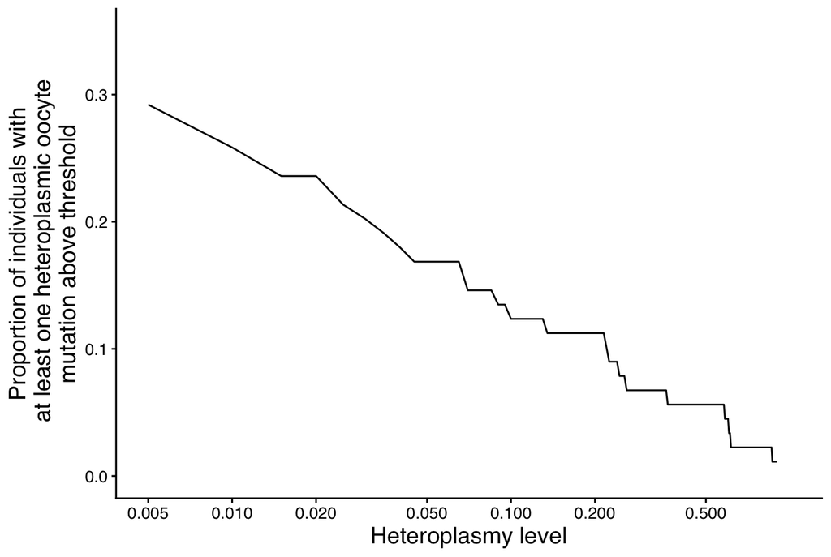

```r
individuals_assessed<-lapply(all_mito_datasets[all_cohorts],function(list) {
  dataset_out<-Map(list2=list,exp_ID=names(list),function(list2,exp_ID){
    if(length(list2$tree$tip.label)<8){return(NULL)} else {return(data.frame(exp_ID=exp_ID,n_samp=length(list2$tree$tip.label)))}
  })%>%dplyr::bind_rows()
  return(dataset_out)
})%>%dplyr::bind_rows()

all_het_oocyte_mut_df<-all_het_oocyte_mut_df%>%filter(!exp_ID%in%c("8 pcw", "18 pcw","CB001","CB002"))
individuals_assessed<-individuals_assessed%>%filter(!exp_ID%in%c("8 pcw", "18 pcw","CB001","CB002"))

n_samples_with_ho_mut_over_threshold<-sapply(seq(0.005,0.9,0.005),function(threshold){all_het_oocyte_mut_df%>%filter(ml_vaf>threshold)%>%distinct(exp_ID)%>%nrow()})

prop_of_samples_with_ho_mut<-data.frame(threshold=seq(0.005,0.9,0.005),n=n_samples_with_ho_mut_over_threshold)%>%
  ggplot(aes(x=threshold,y=n/nrow(individuals_assessed)))+
  geom_line()+
  theme_classic()+
  scale_y_continuous(limits=c(0,0.35))+
  scale_x_log10(limits=c(0.005,1),breaks=c(0.005,0.01,0.02,0.05,0.1,0.2,0.5))+
  my_markdown_theme+
  labs(x="Heteroplasmy level",y="Proportion of individuals with\n at least one heteroplasmic oocyte\nmutation above threshold")
prop_of_samples_with_ho_mut
```

```r
save_plot(filename = paste0(plots_dir,"prop_of_samples_with_ho_mut.pdf"),prop_of_samples_with_ho_mut,width=2.5,height=1.8)
```

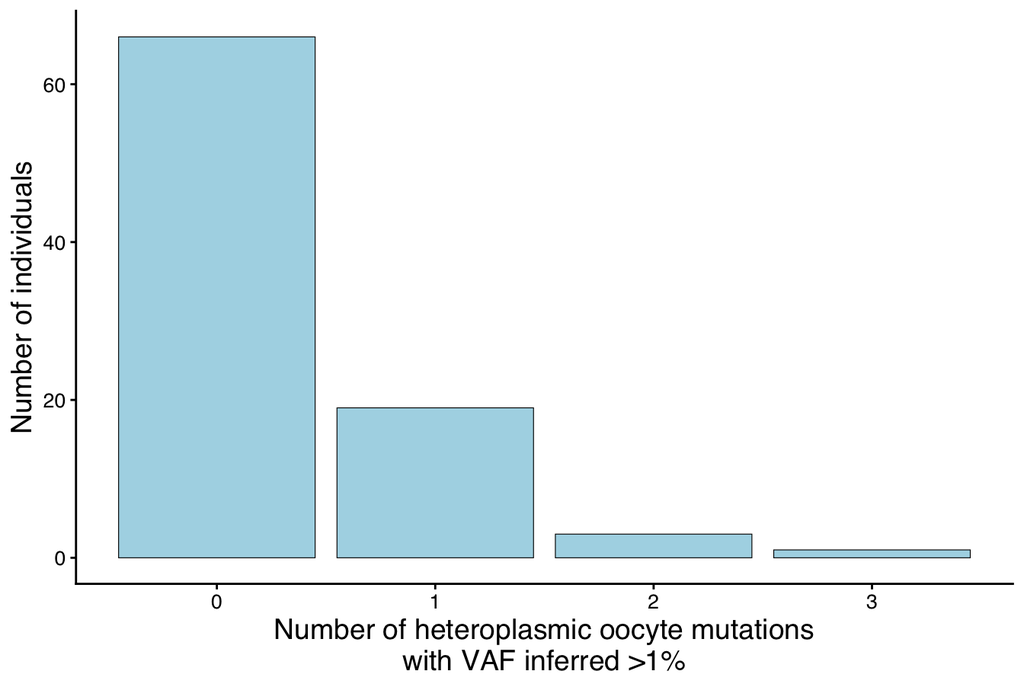

```r
library(dndscv)
library(mitovizR)

all_mtDNA_genes <- c("MT-CYB", "MT-ND5", "MT-ND2", "MT-ND4", "MT-ND1", "MT-CO3", "MT-ATP6","MT-ND3", "MT-ATP8", "MT-ND4L", "MT-CO2", "MT-CO1","MT-ND5","MT-ND6")
mtref_rda_path=ifelse(Sys.info()['sysname']=="Darwin",paste0(root_dir,"/data/mtref.rda"),"/lustre/scratch126/casm/team154pc/ms56/Mitochondria_study/mtref.rda")

# read in the mtdna variant file and remove patient id
mtdna.variant.data <- all_het_oocyte_mut_df%>%
  separate("mut_ref", c("chr", "pos", "ref", "mut"), "_")%>%
  mutate(pos=as.numeric(pos))%>%
  dplyr::select("sampleID"=exp_ID,chr,pos,ref,mut)%>% # next, rename/reorder the columns to make them compatible with dnds input format
  dplyr::filter(!duplicated(.))%>% # remove duplicated variants
  arrange(sampleID,pos)

mtdna.dndsout <- dndscv(mtdna.variant.data,
                        gene_list=all_mtDNA_genes,
                        refdb = mtref_rda_path,
                        numcode=2,
                        max_coding_muts_per_sample = Inf,
                        max_muts_per_gene_per_sample = Inf)

all_het_oocyte_mut_df_annotated<-all_het_oocyte_mut_df%>%
  tidyr::separate(mut_ref,into=c("chr","pos","ref","mut"),sep = "_")%>%
  mutate(pos=as.numeric(pos))%>%
  left_join(mtdna.dndsout$annotmuts,by=c("chr","pos","ref","mut"),relationship = "many-to-many")%>%
  replace_na(replace=list(impact="Non-coding"))

#Create a coordinate reference for the different regions----
mito_domain_convert<-c("tRNA","rRNA","Coding","D-loop")
names(mito_domain_convert)<-c("trna","rrna","cds","reg")

mito_coords_reference_df<-mitovizR:::mito_df()%>%
  dplyr::select(type,ymin,ymax)%>%
  dplyr::mutate(Mutation_type=mito_domain_convert[type])

all_het_oocyte_mut_df_annotated$Mutation_type<-sapply(all_het_oocyte_mut_df_annotated$pos,
                                                      function(pos) {mito_coords_reference_df$Mutation_type[mito_coords_reference_df$ymin<pos & mito_coords_reference_df$ymax>=pos]})

het_oocyte_mut_type_summary<-all_het_oocyte_mut_df_annotated%>%
  dplyr::filter(!grepl("\\*",mut))%>%
  dplyr::mutate(final_type=ifelse(is.na(impact)|impact=="Non-coding",Mutation_type,impact),
                cat=ifelse(ml_vaf>=0.01,"Heteroplasmic\noocyte\n(VAF≥1%)","Heteroplasmic\noocyte\n(VAF<1%)"))%>%
  group_by(cat,final_type)%>%
  dplyr::summarise(n=n())%>%
  dplyr::mutate(prop=n/sum(n))


#Plot barplot showing number of het oocyte muts per individual----
n_of_het_oocyte_muts_plot<-all_het_oocyte_mut_df_annotated%>%
  dplyr::filter(!grepl("\\*",mut) & ml_vaf>0.01)%>%
  group_by(exp_ID)%>%
  dplyr::summarise(nmut=n())%>%
  right_join(individuals_assessed)%>%
  replace_na(list(nmut=0))%>%
  dplyr::group_by(nmut)%>%
  dplyr::summarise(n_samples=n())%>%
  ggplot(aes(x=nmut,y=n_samples))+
  geom_bar(stat="identity",col="black",linewidth=0.2,fill="lightblue")+
  theme_classic()+
  my_markdown_theme+
  labs(x="Number of heteroplasmic oocyte mutations\nwith VAF inferred >1%",y="Number of individuals")

n_of_het_oocyte_muts_plot
```

```r
save_plot(filename = paste0(plots_dir,"n_of_het_oocyte_muts_plot.pdf"),n_of_het_oocyte_muts_plot,width=2,height=1.8)
```

Compare mutation distribution with full somatic mutation set

```r
complete.annotated.mutation.table$Mutation_type<-sapply(complete.annotated.mutation.table$pos,
       function(pos) {mito_coords_reference_df$Mutation_type[mito_coords_reference_df$ymin<pos & mito_coords_reference_df$ymax>=pos]})

Mut_type_levels=c("D-loop","Synonymous","tRNA","rRNA","Missense","Stop_loss","Nonsense","Inconsistent\nannotation")
Mut_cat_comparison<-het_oocyte_mut_type_summary%>%
  dplyr::bind_rows(complete.annotated.mutation.table%>%
                     dplyr::mutate(final_type=ifelse(impact=="Non-Coding"&Mutation_type=="Coding","Inconsistent\nannotation",ifelse(is.na(impact)|impact=="Non-Coding",Mutation_type,impact)))%>%
                     group_by(final_type)%>%
                     dplyr::summarise(n=n())%>%
                     dplyr::mutate(prop=n/sum(n),cat="Somatic"))%>%
  mutate(final_type=factor(final_type,levels=Mut_type_levels))%>%
  ggplot(aes(x=cat,y=prop,fill=forcats::fct_rev(final_type)))+
  geom_bar(stat="identity",position = "fill",col="black",linewidth=0.2)+
  theme_classic()+
  scale_y_continuous(breaks=seq(0,1,0.1))+
  scale_fill_brewer(palette = "Set2",direction = -1)+
  my_markdown_theme+
  labs(fill="Mutation\ncategory",x="",y="Proportion")

het_oocyte_mut_type_summary%>%
  dplyr::bind_rows(complete.annotated.mutation.table%>%
                     dplyr::mutate(final_type=ifelse(impact=="Non-Coding"&Mutation_type=="Coding","Inconsistent\nannotation",ifelse(is.na(impact)|impact=="Non-Coding",Mutation_type,impact)))%>%
                     group_by(final_type)%>%
                     dplyr::summarise(n=n())%>%
                     dplyr::mutate(prop=n/sum(n),cat="Somatic"))%>%
  group_by(cat)%>%dplyr::summarise(n=sum(n))
```

```
## # A tibble: 3 × 2
##   cat                                   n
##   <chr>                             <int>
## 1 "Heteroplasmic\noocyte\n(VAF<1%)"    49
## 2 "Heteroplasmic\noocyte\n(VAF≥1%)"    27
## 3 "Somatic"                         11965
```

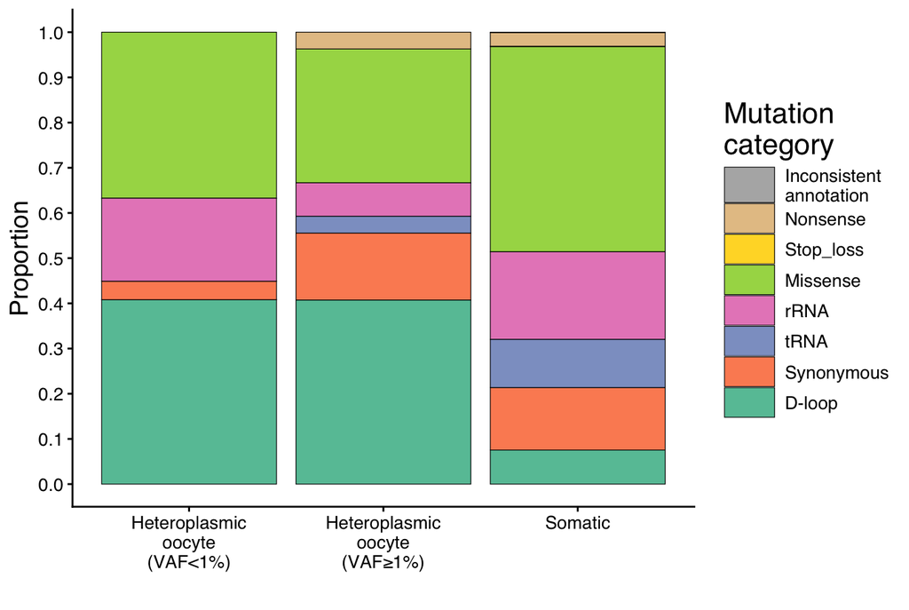

```r
Mut_cat_comparison
```

```r
save_plot(filename = paste0(plots_dir,"Mut_cat_comparison.pdf"),Mut_cat_comparison,width=3,height=2.5)
```

Save plot of het oocyte mutations by genome position.

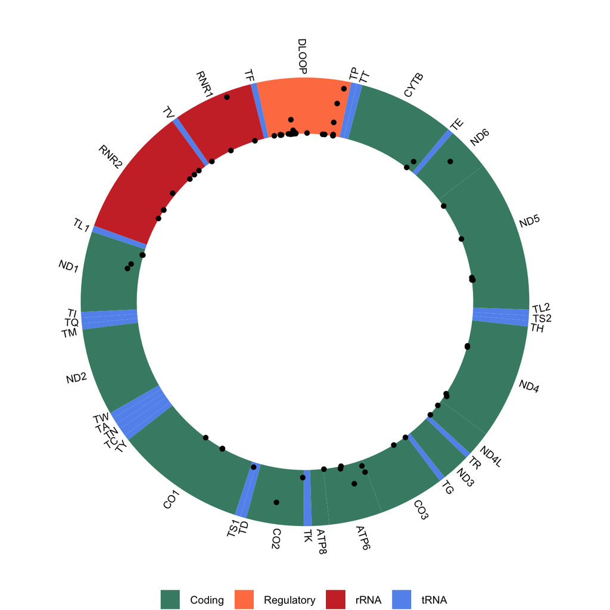

```r
mtDNA_mut_pos<-plot_df(all_het_oocyte_mut_df_annotated%>%
                         dplyr::filter(!grepl("\\*",mut))%>%
          dplyr::mutate(SAMPLE="all")%>%
          dplyr::select(SAMPLE,pos,ref,mut,"HF"=ml_vaf),
          pos_col = "pos", ref_col = "ref", alt_col = "mut")
mtDNA_mut_pos
```

```r
save_plot(filename = paste0(plots_dir,"mtDNA_mut_pos.pdf"),mtDNA_mut_pos,width=5,height=5)
```

## Do example clone inferences on an individuals with heteroplasmic oocyte muts

This is to demonstrate how inferring clones without considering the possibility of heteroplasmic oocyte mutations can completely misinform the inference. This is not always the case, but is an issue in selected cases.

```r
library(Seurat)
library(ComplexHeatmap)
library(BuenColors)

#Define function to get clusters
seuratSNN <- function(matSVD, resolution = 1, k.param = 10){
  set.seed(1)
  rownames(matSVD) <- make.unique(rownames(matSVD))
  obj <- FindNeighbors(matSVD, k.param = k.param, annoy.metric = "cosine")
  clusters <- FindClusters(object = obj$snn, resolution = resolution)
  return(as.character(clusters[,1]))
}

output.dir <- paste0(root_dir,"/data/mito_mut_clones/nonblood/")
dir.create(output.dir,showWarnings = F)

# store the information for the heatmap here
df.list <- list()
matrix.list <- list()

# iterate over multiple patients here (if there are multiple)
patient.info<-data.frame(dataset=c("NW","PR","PR","LM"),patient.id=c("PD5182","PD44887","PD44890","PD41857"))

for (i in 1:nrow(patient.info)){

  # read in one of the mgatk SE objects
  patient.tmp <- patient.info$patient.id[i]
  patient.dataset <- patient.info$dataset[i]
  cat(paste0("\nProcessing patient...", patient.tmp, "\n"))
  this.patient.info<-all_mito_datasets[[patient.dataset]][[patient.tmp]]
  vaf.mtx <- this.patient.info$matrices$vaf.filt

  #Remove mutations present in all samples & keep only those present at global VAF >0.5%
  if(is.null(this.patient.info$matrices$vaf$global)){
    this.patient.info$matrices$vaf$global<-rowSums(this.patient.info$matrices$NV)/rowSums(this.patient.info$matrices$NR)
  }
  high_global_vaf_muts<-rownames(this.patient.info$matrices$vaf)[this.patient.info$matrices$vaf$global>0.005]
  vaf.mtx<-vaf.mtx[rownames(vaf.mtx)%in%high_global_vaf_muts &
                     !grepl("INS|DEL",rownames(vaf.mtx)),]
  if(any(colnames(vaf.mtx)=="global")) {
    vaf.mtx<-vaf.mtx[,-which(colnames(vaf.mtx)=="global")]
  }

  # filter them according to a certain mean coverage
  # coverage.data <- coverage.data %>%  dplyr::filter(mean_cov >= 10)

  # remove variants which are not present at a VAF > 1% at least once
  mutations <- rownames(vaf.mtx)
  filtered.mutations <- mutations[rowSums(vaf.mtx > 0.01) > 1]
  vaf.filtered.mtx <- vaf.mtx[filtered.mutations,]

  #-----------------------------------------------------------------------------------#
  ## Define clones based on the mitochondrial mutations -------------------------------
  #-----------------------------------------------------------------------------------#

  # get clusters with cluster resolution 10 and knn 50
  # clustering fails for PD41857 with these parameters, so empirically altered to optimize
  #if(patient.tmp=="PD41857"){
    clusters <- seuratSNN((t(vaf.filtered.mtx)),resolution= 5,k.param=3)
  # } else {
  #   clusters <- seuratSNN((t(vaf.filtered.mtx)),resolution= 10,k.param=5)
  # }

  clusters <- str_pad(clusters, 2, pad = "0")

  # assign colours to clusters
  names_clusters <- unique(clusters)
  cluster_cols<- c("lightgray","#1f77b4","#d62728","#2ca02c","#ff7f0e","#9467bd","#8c564b","#e377c2","#7f7f7f","#bcbd22","#17becf","#ad494a","#e7ba52","#8ca252","#756bb1","#636363","#aec7e8", brewer.pal(12, "Paired"))
  vec_go <- cluster_cols[1:length(names_clusters)]
  names(vec_go) <- sort(names_clusters)

  #Change the colour of the biggest cluster to light grey - this is generally the "NULL" cluster with no informative mutations
  biggest_cluster<-names(table(clusters))[which.max(table(clusters))]
  original_cluster_0<-which(clusters=="00")
  new_cluster_0<-which(as.character(clusters)==biggest_cluster)
  clusters[new_cluster_0]<-"00"
  clusters[original_cluster_0]<-biggest_cluster

  # Make data.frame for cluster_id and sample relationship
  df <- data.frame(
    sample_id = colnames(vaf.filtered.mtx),
    cluster_id = as.character(clusters),
    stringsAsFactors = F
  ) %>% arrange(clusters)

  #Work out which cluster is the 'no shared muts' cluster and give a bland colour
  mean_cluster_muts<-sapply(unique(clusters),function(no){
    cluster_samples<-df%>%dplyr::filter(cluster_id==no)%>%pull(sample_id)
    sum((vaf.filtered.mtx[,cluster_samples]>0.01))/length(cluster_samples)
  })

  min_mut_cluster<-unique(clusters)[which.min(mean_cluster_muts)]
  # vec_go[min_mut_cluster]<-"lightgrey"
  df <- df[!duplicated(df),]

  # store the df
  df.list[[i]] <- df
  write.table(df, paste0(output.dir, "/", patient.tmp, "_mtdna_clone_assignment.txt"), col.names = T, row.names = F, quote = F, sep = "\t")

  #-----------------------------------------------------------------------------------#
  ## Create a heatmap -------------------------------
  #-----------------------------------------------------------------------------------#

  # make a heatmap annotation
  ha_col <- HeatmapAnnotation(Cluster = as.character(df$cluster_id),
                              col = list(Cluster = vec_go))

  # replace variants below 1% VAF
  afp <- vaf.filtered.mtx
  aftree <- afp
  #afp[afp < 0.01] <- 0
  afp[afp > 0.1] <- 0.1

  # order the mutations according to abundance
  mean_vaf <- rowMeans(afp)
  mut_order <- names(mean_vaf[order(mean_vaf, decreasing = T)])
  ordered_afp <- afp[mut_order,]
  colnames(ordered_afp) <- paste0(df$sample_id, "_", colnames(ordered_afp))

  # store the other matrix as well
  matrix.list[[i]] <- data.matrix(ordered_afp)

  # cluster hierarchically within each group
  # here we define the groups we want to cluster according to
  groups <- unique(clusters)[order(unique(clusters))]
  ordered_names <- c()

  # perform hierarchical clustering within each cluster
  k <- 1
  for (k in 1:length(groups)){

    # which group?
    print(groups[k])

    # get the barcodes from the respective group
    barcodes <- df[grep(groups[k], df$cluster_id), "sample_id"]

    if (length(barcodes) > 1){
      # iterate over all chrs and subset the matrix
      matrix <- vaf.filtered.mtx[,colnames(vaf.filtered.mtx) %in% barcodes]
      avgd <- colMeans(matrix)

      # Order cells with hierarchical clustering
      dist.centered.matrix <- stats::dist(as.matrix(avgd), method = "euclidean")
      hc <- hclust(dist.centered.matrix, method = "ward.D2")

      # make a vector with the right order of barcodes per group
      ordered_names <- c(ordered_names, hc$labels[hc$order])

    } else {
      next
    }

  }

  hm <- Heatmap((data.matrix(afp)[,as.character(ordered_names)]),  # var_order
                col=as.character(BuenColors::jdb_palette("solar_rojos",type="continuous")),
                show_row_names = FALSE,
                top_annotation=ha_col,
                cluster_columns = FALSE,
                name = "AF",use_raster = FALSE,
                row_names_gp = gpar(fontsize = 10),
                cluster_rows = TRUE,
                show_column_names = FALSE)

  # save heatmaps
  save_pdf(paste0(plots_dir, patient.tmp, "_mito_mutation_heatmap.pdf"), width=15, height=8)
  print(hm)
  dev.off()

  #-----------------------------------------------------------------------------------#
  ## Create "trees" aka dendrograms ---------------------------------------------------
  #-----------------------------------------------------------------------------------#

  # Get group means
  matty <- sapply(names(vec_go), function(cluster){
    cells <- df %>% dplyr::filter(cluster_id == cluster) %>% pull(sample_id) %>% as.character()
    Matrix::rowMeans(sqrt(afp[,cells]))
  })

  if(length(groups) > 2){

    # Do cosine distance; note that we used sqrt transformation already when creating the pseudo bulk-cell matrix
    mito.hc <- hclust(stats::dist(lsa::cosine((matty))))

    save_pdf(paste0(plots_dir, patient.tmp, "_hierarchical_tree.pdf"), width = 5, height = 5)
    print(plot(mito.hc))
    dev.off()

  } else {
    next
  }
}
```

```
##
## Processing patient...PD5182
```

```
## Modularity Optimizer version 1.3.0 by Ludo Waltman and Nees Jan van Eck
##
## Number of nodes: 159
## Number of edges: 1816
##
## Running Louvain algorithm...
## Maximum modularity in 10 random starts: 0.0560
## Number of communities: 47
## Elapsed time: 0 seconds
```

```
## 28 singletons identified. 19 final clusters.
```

```
## [1] "00"
## [1] "01"
## [1] "02"
## [1] "03"
## [1] "04"
## [1] "05"
## [1] "06"
## [1] "07"
## [1] "08"
## [1] "09"
## [1] "10"
## [1] "11"
## [1] "12"
## [1] "13"
## [1] "14"
## [1] "15"
## [1] "16"
## [1] "17"
## [1] "18"
```

```
## NULL
##
## Processing patient...PD44887
```

```
## Modularity Optimizer version 1.3.0 by Ludo Waltman and Nees Jan van Eck
##
## Number of nodes: 31
## Number of edges: 182
##
## Running Louvain algorithm...
## Maximum modularity in 10 random starts: -0.1434
## Number of communities: 20
## Elapsed time: 0 seconds
```

```
## 16 singletons identified. 4 final clusters.
```

```
## [1] "00"
## [1] "01"
## [1] "02"
## [1] "03"
```

```
## NULL
##
## Processing patient...PD44890
```

```
## Modularity Optimizer version 1.3.0 by Ludo Waltman and Nees Jan van Eck
##
## Number of nodes: 49
## Number of edges: 213
##
## Running Louvain algorithm...
## Maximum modularity in 10 random starts: 0.0822
## Number of communities: 23
## Elapsed time: 0 seconds
```

```
## 13 singletons identified. 10 final clusters.
```

```
## [1] "00"
## [1] "01"
## [1] "02"
## [1] "03"
## [1] "04"
## [1] "05"
## [1] "06"
## [1] "07"
## [1] "08"
## [1] "09"
```

```
## NULL
##
## Processing patient...PD41857
```

```
## Modularity Optimizer version 1.3.0 by Ludo Waltman and Nees Jan van Eck
##
## Number of nodes: 13
## Number of edges: 39
##
## Running Louvain algorithm...
## Maximum modularity in 10 random starts: -0.4126
## Number of communities: 9
## Elapsed time: 0 seconds
```

```
## 6 singletons identified. 3 final clusters.
```

```
## [1] "00"
## [1] "01"
## [1] "02"
```

Import clustered clones to overlay onto true tree.

```r
par(mfrow=c(2,2))
cluster_cols<- c("lightgray","#1f77b4","#d62728","#2ca02c","#ff7f0e","#9467bd","#8c564b","#e377c2","#7f7f7f",
                 "#bcbd22","#17becf","#ad494a","#e7ba52","#8ca252","#756bb1","#636363","#aec7e8", brewer.pal(12, "Paired"))
length(cluster_cols)
```

```
## [1] 29
```

```
## scale= 200
```

```
## scale= 200
```

```
## scale= 5000
```

```
## scale= 5000
```

```
## scale= 5000
```

```
## scale= 5000
```

```
## scale= 200
```

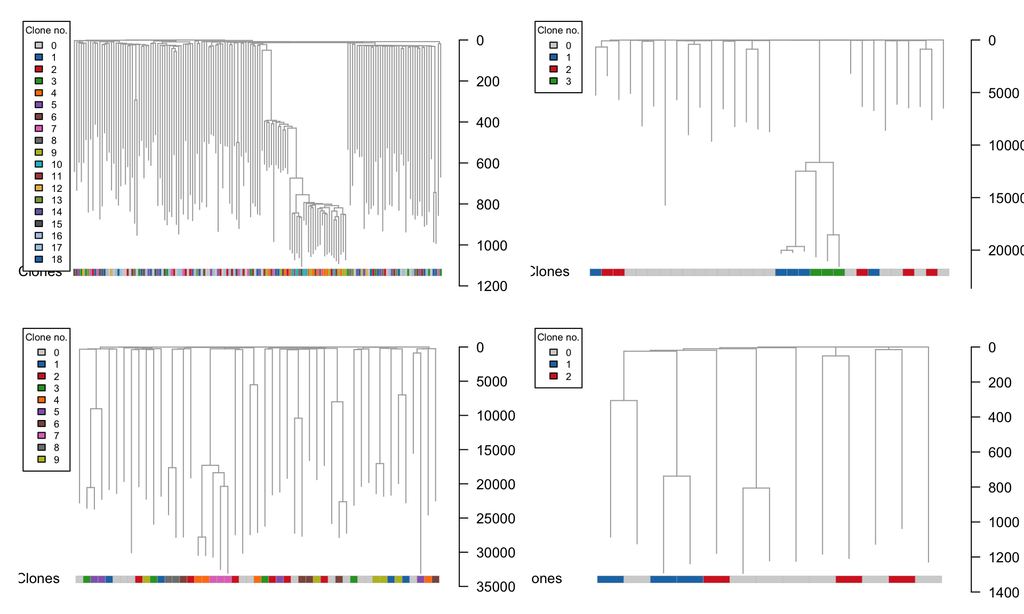

```
## scale= 200
```

```r
for(j in 1:nrow(patient.info)) {

  patient.tmp <- patient.info$patient.id[j]
  patient.dataset <- patient.info$dataset[j]

  this.patient.info<-all_mito_datasets[[patient.dataset]][[patient.tmp]]
  exp_clones<-read.delim(paste0(output.dir, "/", patient.tmp, "_mtdna_clone_assignment.txt"))
  n_clones<-length(unique(exp_clones$cluster_id))
  exp_cluster_cols<-cluster_cols[1:n_clones]
  names(exp_cluster_cols)<-unique(exp_clones$cluster_id)

  #Change the colour of the biggest cluster to light grey
  biggest_cluster<-names(table(exp_clones$cluster_id))[which.max(table(exp_clones$cluster_id))]
  original_cluster_0<-which(exp_clones$cluster_id==0)
  new_cluster_0<-which(as.character(exp_clones$cluster_id)==biggest_cluster)
  exp_clones$cluster_id[new_cluster_0]<-0
  exp_clones$cluster_id[original_cluster_0]<-as.integer(biggest_cluster)

  #Plot the tree annotated with the clusters
  this.patient.info$tree=plot_tree(tree = this.patient.info$tree,cex.label = 0)
  clone_hm<-matrix(NA,nrow=1,ncol=length(this.patient.info$tree$tip.label),dimnames = list("Clones",this.patient.info$tree$tip.label))
  for(i in 1:nrow(exp_clones)){
    if(exp_clones$sample_id[i]%in%this.patient.info$tree$tip.label){
      clone_hm[1,exp_clones$sample_id[i]]<-exp_cluster_cols[as.character(exp_clones$cluster_id[i])]
    }
  }

  add_heatmap(tree=this.patient.info$tree,heatmap=clone_hm,border="gray",cex.label = 1)
  legend("topleft", inset=c(.01,.01), title="Clone no.",
         names(exp_cluster_cols), fill=exp_cluster_cols, horiz=F, cex=0.7,ncol=1)

  #Now save it
  save_pdf(file=paste0(plots_dir,"Inferred_clones_",patient.tmp,".pdf"),width = 7,height=3)
  par(mfrow=c(1,1))
  this.patient.info$tree=plot_tree(tree = this.patient.info$tree,cex.label = 0)
  clone_hm<-matrix(NA,nrow=1,ncol=length(this.patient.info$tree$tip.label),dimnames = list("Clones",this.patient.info$tree$tip.label))
  for(i in 1:nrow(exp_clones)){
    if(exp_clones$sample_id[i]%in%this.patient.info$tree$tip.label){
      clone_hm[1,exp_clones$sample_id[i]]<-exp_cluster_cols[as.character(exp_clones$cluster_id[i])]
    }
  }

  add_heatmap(tree=this.patient.info$tree,heatmap=clone_hm,border="gray",cex.label = 1)
  legend("topleft", inset=c(.01,.01), title="Clone no.",
         names(exp_cluster_cols), fill=exp_cluster_cols, horiz=F, cex=0.7,ncol=1)
  dev.off()
  this.patient.info$clusters<-exp_clones
  this.patient.info$cluster_cols<-exp_cluster_cols
  this.patient.info$cluster_hm<-clone_hm
}
```